# machineLearningProject3

Alexander Reyes

November 14, 2014

```r
library(caret)
dat <- read.csv('pml-training.csv')
colNames <- names(dat)
measuredVars<- grep('dumbbell|arm|belt|glove', colNames)

factorVars <- grep('factor', sapply(dat, class))
factorCandidates <- colNames[c(-(1:7), -factorVars)]

preObj <- preProcess(dat[, factorCandidates],method=c("knnImpute"))
processedFactorCandidates <- predict(preObj, dat[, factorCandidates])
finalData <- data.frame(processedFactorCandidates, classe=dat[, 'classe'])
```

The difficulty with data set is the number of possible predictors and the fact that many are read as ‘factors’. The latter group seems to have a lot of NA’s admixed with some strings which causes read.csv to fail is numeric types are enforced. Factor variables cause problems with preprocessing so I tried to not consider them as there were so many NA’s anyway. This left the “factorCandidates” vector as the variables to be considered in the model.

knnImpute was used to fill in NA’s in the factorCandidates. I used p=0.3 to save time on the training for the knit html call.

Models were fitted for simple tree(‘rpart’), random forest (‘rf’) and boosted trees (‘gbm’)

```r
inTrain <- createDataPartition(y=finalData$classe, p=0.3, list=FALSE)
training <- finalData[inTrain, ]
testing <- finalData[-inTrain, ]
rm(dat)
```

```r
model.rpart <- train(classe ~ ., method='rpart', data=training)
model.gbm <- train(classe ~ ., method='gbm', data=training)
model.rf <- train(classe ~ ., method='rf', data=training)
pred.rpart <- predict(model.rpart, testing)
pred.rf <- predict(model.rf, testing)
pred.gbm <- predict(model.gbm, testing)


conf.rpart <- confusionMatrix(pred.rpart, testing$classe)
conf.rf <- confusionMatrix(pred.rf, testing$classe)
conf.gbm <- confusionMatrix(pred.gbm, testing$classe)


#Accuracy and Kappa values for the 3 models
#rpart
conf.rpart$overall['Accuracy']
```

```
## Accuracy
##   0.5694
```

```r
conf.rpart$overall['Kappa']
```

```
##  Kappa
## 0.4528
```

```r
#rf
conf.rf$overall['Accuracy']
```

```
## Accuracy
##   0.9744
```

```r
conf.rf$overall['Kappa']
```

```
##  Kappa
## 0.9676
```

```r
#gbm
conf.gbm$overall['Accuracy']
```

```
## Accuracy
##   0.9508
```

```r
conf.gbm$overall['Kappa']
```

```
##  Kappa
## 0.9377
```

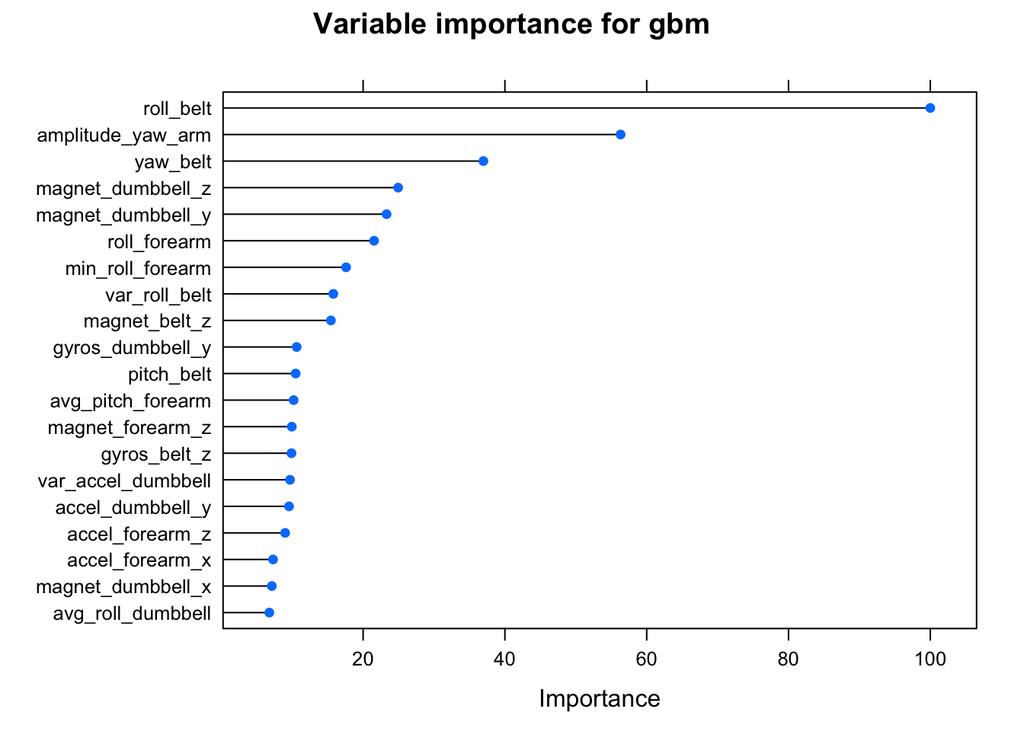

```r
gbmImp <- varImp(model.gbm)
plot(gbmImp, top=20, main="Variable importance for gbm")
```

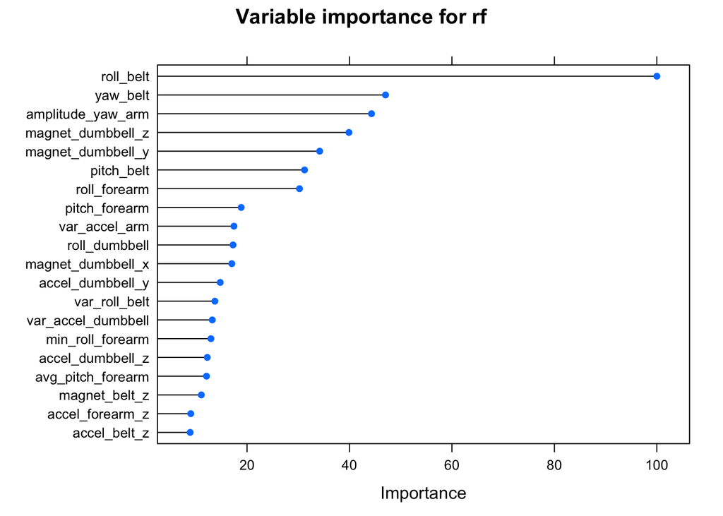

```r
rfImp<- varImp(model.rf)
plot(rfImp, top=20, main="Variable importance for rf")
```